# Proyecto Final

Karina Bonilla Fuentes

2025-05-23

## Cargar Paquetes Necesarios

```r
# install.packages(c("ggplot2", "dplyr", "tidyr","tibble"))

library(ggplot2)
library(dplyr)
library(tidyr)
library(tibble)
```

## 1- Cargar un dataset

```r
data <- read.csv("menores_viajan.csv")
head(data)
```

```
##   Clave_de_AGEE            formato anio_mes Menores_que_viajan
## 1             1                sam  2018-01               2063
## 2             2           notarial  2018-01                113
## 3             3 autoridad judicial  2018-01                  3
## 4             1                sam  2018-02               1912
## 5             2           notarial  2018-02                269
## 6             3 autoridad judicial  2018-02                  8
```

```r
str(data)
```

```
## 'data.frame':    261 obs. of  4 variables:
##  $ Clave_de_AGEE     : int  1 2 3 1 2 3 1 2 3 1 ...
##  $ formato           : chr  "sam" "notarial" "autoridad judicial" "sam" ...
##  $ anio_mes          : chr  "2018-01" "2018-01" "2018-01" "2018-02" ...
##  $ Menores_que_viajan: int  2063 113 3 1912 269 8 3361 295 2 3204 ...
```

```r
summary(data)
```

```
##  Clave_de_AGEE   formato            anio_mes         Menores_que_viajan
##  Min.   :1     Length:261         Length:261         Min.   :    0
##  1st Qu.:1     Class :character   Class :character   1st Qu.:    2
##  Median :2     Mode  :character   Mode  :character   Median :   89
##  Mean   :2                                           Mean   : 1217
##  3rd Qu.:3                                           3rd Qu.: 1735
##  Max.   :3                                           Max.   :12230
##                                                      NA's   :9
```

```r
colSums(is.na(data))#--VER SI HAY DATOS FALTANTEs
```

```
##      Clave_de_AGEE            formato           anio_mes Menores_que_viajan
##                  0                  0                  0                  9
```

```r
datos_limpios <- na.omit(data)#--quitar vacios
colSums(is.na(datos_limpios))#--VER SI HAY DATOS FALTANTEs
```

```
##      Clave_de_AGEE            formato           anio_mes Menores_que_viajan
##                  0                  0                  0                  0
```

## 2- Calcular medidas de tendencia central

```r
media <- mean(data$Menores_que_viajan, na.rm= TRUE)
mediana <-median(data$Menores_que_viajan, na.rm= TRUE)
desviacion <-sd(data$Menores_que_viajan, na.rm= TRUE)
datos_limpios %>% filter(formato == 'notarial')
```

```
##    Clave_de_AGEE  formato anio_mes Menores_que_viajan
## 1              2 notarial  2018-01                113
## 2              2 notarial  2018-02                269
## 3              2 notarial  2018-03                295
## 4              2 notarial  2018-04                334
## 5              2 notarial  2018-05                203
## 6              2 notarial  2018-06                453
## 7              2 notarial  2018-07                243
## 8              2 notarial  2018-08                105
## 9              2 notarial  2018-09                 51
## 10             2 notarial  2018-10                 96
## 11             2 notarial  2018-11                319
## 12             2 notarial  2018-12                 91
## 13             2 notarial   2019-4                513
## 14             2 notarial   2019-5                255
```

[output cut: 70 more lines]

```r
datos_limpios %>% filter(anio_mes == '2018-03')
```

```
##   Clave_de_AGEE            formato anio_mes Menores_que_viajan
## 1             1                sam  2018-03               3361
## 2             2           notarial  2018-03                295
## 3             3 autoridad judicial  2018-03                  2
```

```r
datos_limpios %>% filter(Menores_que_viajan>1000)
```

```
##    Clave_de_AGEE formato anio_mes Menores_que_viajan
## 1              1     sam  2018-01               2063
## 2              1     sam  2018-02               1912
## 3              1     sam  2018-03               3361
## 4              1     sam  2018-04               3204
## 5              1     sam  2018-05               4408
## 6              1     sam  2018-06               7189
## 7              1     sam  2018-07               5486
## 8              1     sam  2018-08               2321
## 9              1     sam  2018-09               1045
## 10             1     sam  2018-10               1414
## 11             1     sam  2018-11               1774
## 12             1     sam  2018-12               2592
## 13             1     sam   2019-4               7938
## 14             1     sam   2019-5               6627
```

[output cut: 61 more lines]

## Including Plots

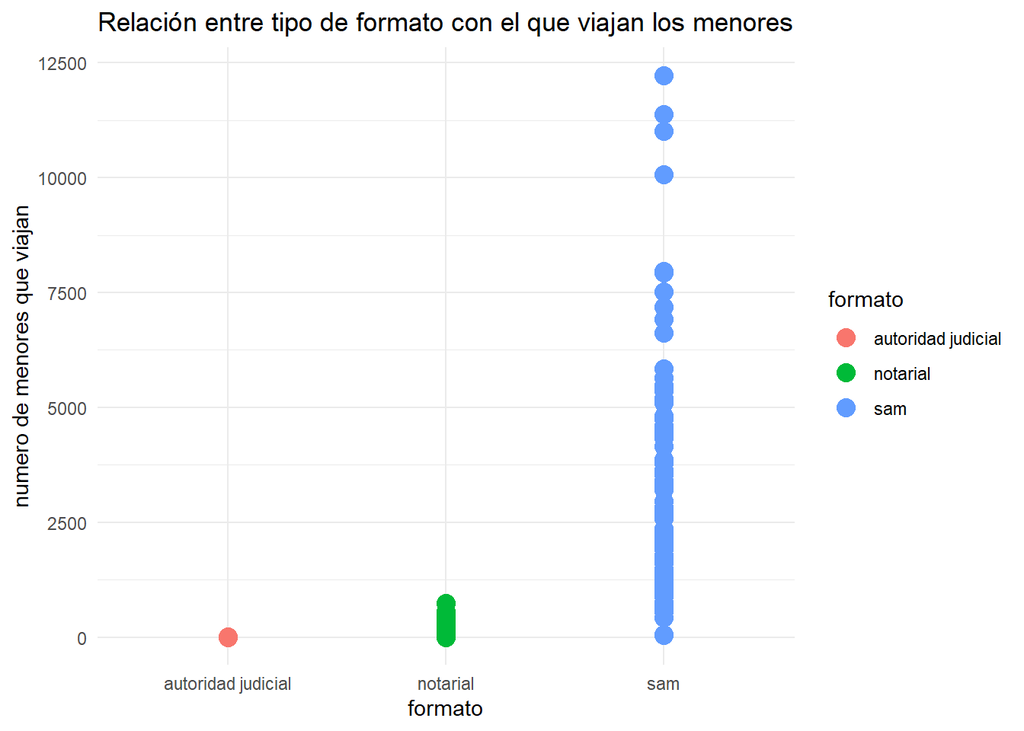

```r
ggplot(datos_limpios, aes(x = formato, y = Menores_que_viajan, color = formato)) +
  geom_point(size = 4) +
  labs(title = "Relación entre tipo de formato con el que viajan los menores",
       x = "formato",
       y = "numero de menores que viajan") +
  theme_minimal()
```

##grafico de caja

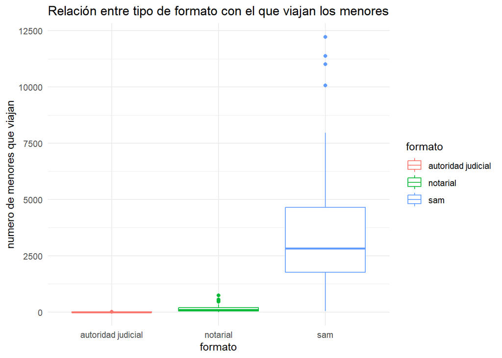

```r
ggplot(datos_limpios, aes(x = formato, y = Menores_que_viajan, color = formato)) +
  geom_boxplot() +
  labs(title = "Relación entre tipo de formato con el que viajan los menores",
       x = "formato",
       y = "numero de menores que viajan") +
  theme_minimal()
```

## Gráfico de barras

[figure not shown]

```r
ggplot(datos_limpios, aes(x = formato, fill = Menores_que_viajan)) +
  geom_bar() +
  labs(title = "Formatos para viajar",
       x = "Formatos",
       y = "Menores que viajan") +
  theme_minimal()
```

## Gráfico de dispersión

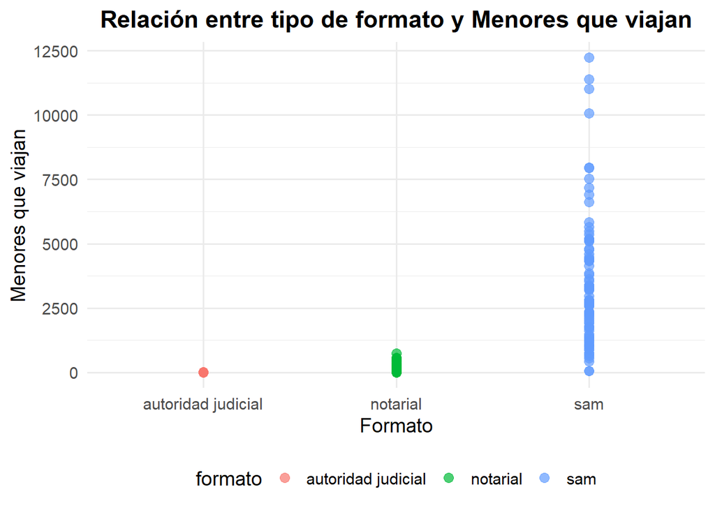

```r
ggplot(datos_limpios, aes(x = formato, y = Menores_que_viajan, color = formato)) +
  geom_point(size = 3, alpha = 0.7) +
  geom_smooth(method = "lm", se = FALSE, color = "black", linetype = "dashed") +
  labs(
    title = "Relación entre tipo de formato y Menores que viajan",
    x = "Formato",
    y = "Menores que viajan",
    color = "formato"
  ) +
  theme_minimal(base_size = 14) +
  theme(
    plot.title = element_text(face = "bold", hjust = 0.5),
    legend.position = "bottom"
  )
```

#grafico de burbujas

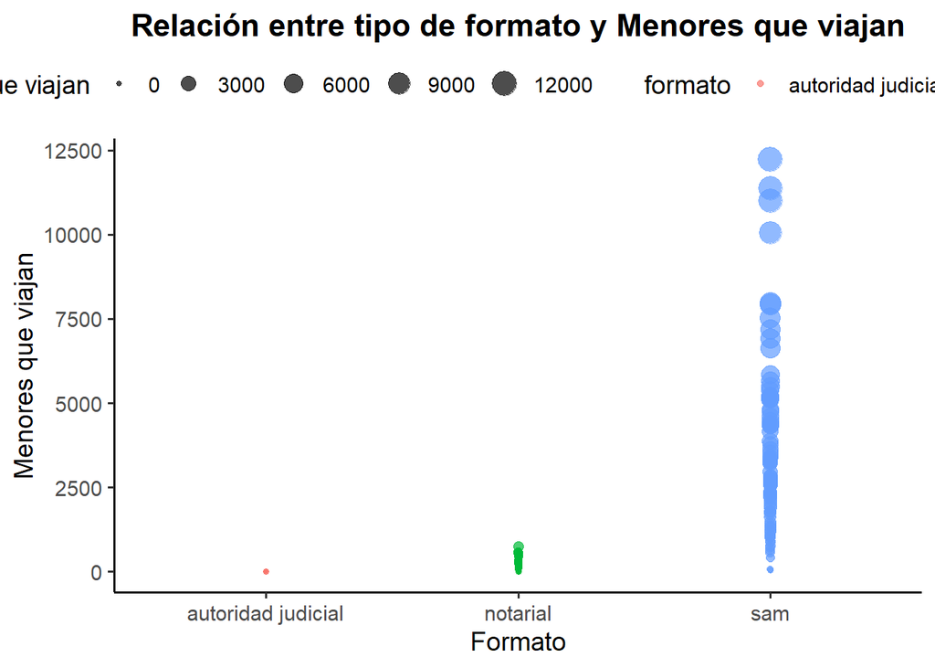

```r
ggplot(datos_limpios, aes(x = formato, y = Menores_que_viajan, size =Menores_que_viajan, color = formato)) +
  geom_point(alpha = 0.7) +
  labs(
    title = "Relación entre tipo de formato y Menores que viajan",
    x = "Formato",
    y = "Menores que viajan",
    size = "Menores que viajan",
    color = "formato"
  ) +
  theme_classic(base_size = 14) +
  theme(
    legend.position = "top",
    plot.title = element_text(hjust = 0.5, face = "bold")
  )
```

## *CONCLUSIONES*

*Hallazgos* En este reporte se encuentra el Registro de menores de edad que viajan al extranjero, solos o en compañía de un tercero: SAM, Notarial, Autoridad judicial entre el 2018 y 2025, siendo el formato SAM el mas usado para dicho tramite, y el de Autoridad judicial el menos usado teniendo datos nulos en varios conteos mensuales.

¿Porque es el formato SAM el más utilizado? Desde el año 2014, el Formato SAM (Formato de Salida de Menores) del Instituto Nacional de Migración (INM) es un documento utilizado como medida de facilitación y protección para evitar que las niñas, niños y adolescentes que viajan solos o con un tercero mayor de edad al extranjero, sean extraídos ilegalmente del país.

El Formato SAM es una alternativa al poder notarial y al documento emitido por la autoridad judicial. A diferencia de estas dos opciones válidas y vigentes, los padres o tutores pueden iniciar la solicitud de manera gratuita a través de la página del INM, las 24 horas de los 365 días del año.

Aunque es un trámite con poca vigencia la facilidad y grautidad para emitirlo provoca que sea el mas usado para los viajes de menores.

No se tienen registros del primer trimestre del año 2019.

*Reflexión* Fue fácil encontrar un dataset con el cual trabajar, internet te proporciona miles de fuentes en distintos formatos para poder trabajar, cada milisegundo se genera un mundo de información, y en esta era tecnológica tener acceso a la información es un derecho de todo ser humas.

Pero, ¿qué haces con esa información? y en es esta pregunta entran todas las ciencias de datos, las herramientas y los conocimientos para una digestión de datos interpretación y conclusiones.

EL análisis de datos no debe ser de unos cuantos, de un sector tecnológico, en cualquier momento y rubro podemos hacer análisis, desde que bus me conviene para una trayectoria revisando tiempos, costos, trayectorias, hasta que empresa es mejor para hacer una inversión teniendo en cuenta intereses, riesgos, inflación, etc.

No hay pretexto para no hacer un analisis de datos!!!

Enlace al proyecto en GitHub https://github.com/KarinaBonillaFuentes/Reporte_analisis_datos

*fin de informe*